# Complexité du tri

Pour évaluer la complexité d'un algorithme de tri, nous allons mesurer

- le nombre de comparaisons
- le nombre d'écritures dans le tableau. (ou d'échanges si c'est plus pertinent).

```python
def tri_a_bulles(T):
    nb_comparaisons = nb_echanges = 0

    N = len(T)
    for k in range(N,1,-1):
        for i in range(0,k-1):
            nb_comparaisons += 1
            if T[i] > T[i+1]:
                nb_echanges += 1
                T[i],T[i+1] = T[i+1],T[i]

    return nb_comparaisons, nb_echanges
```

Enfin, il convient d'effectuer les mesures pour diverses tailles de tableau et éventuellement divers contenus.

La fonction qui suit teste 50 tailles allant de 10 à 1000 selon une progression géométrique (facteur multiplicatif constant).

Générer le contenu du tableau est sous-traité à la fonction genere_tab passée en paramètre.

```python
def evalue_complexite(algorithme, genere_tab, nom):

    C1 = []
    C2 = []
    X = [ int(x) for x in np.logspace(1,3,50) ]

    for n in X:
        T = genere_tab(n)
        comp, ech = algorithme(T)
        C1.append(comp)
        C2.append(ech)

    affiche_complexite(X,C1,C2,nom)
```

Evaluons d'abord la complexité du tri d'un tableau au contenu généré aléatoirement.

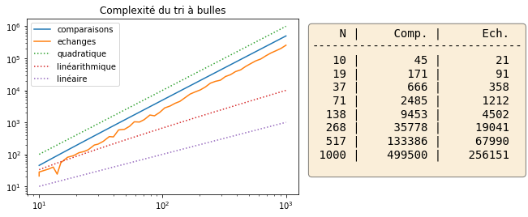

```python
def tab_aleatoire(n): return np.random.uniform(0,1,n)
evalue_complexite(tri_a_bulles, tab_aleatoire, "tri à bulles")
```

Nous voyons que tant le nombre de comparaisons que le nombre d'échanges ont une **complexité quadratique $\Theta(n^2)$** pour trier $n$ éléments.

Pour être plus précis

- le nombre de comparaisons est exactement $n(n-1)/2$
- le nombre d'échanges varie selon le contenu mais est de l'ordre de $n^2/4$

Il sera souvent pertinent d'effectuer deux autres tests pour évaluer la complexité de nos algorithmes.

Le premier test consiste à trier un tableau déjà parfaitement trié.

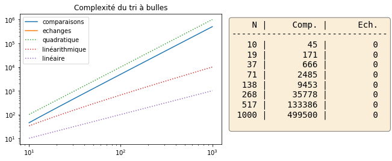

```python
def tableau_trie(n): return range(n)
evalue_complexite(tri_a_bulles, tableau_trie, "tri à bulles")
```

Le nombre de comparaisons ne dépend pas du contenu du tableau.

Le nombre d'échanges est uniformément nul.

Le deuxième test utilise un tableau en ordre décroissant.

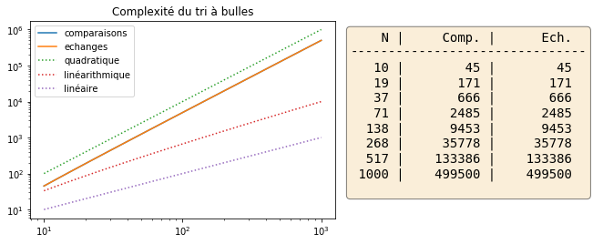

```python
def tableau_inverse(n): return list(range(n,0,-1))
evalue_complexite(tri_a_bulles, tableau_inverse, "tri à bulles")
```

Le nombre de comparaisons est inchangé mais le nombre d'échanges est égal au nombre de comparaisons.

Tous les tests de comparaisons renvoient `True`, il y a échange à chaque fois.

Notons que cela ne change rien à la complexité du tri à bulles qui est toujours dominée par celle du nombre de comparaisons.

La complexité du tri à bulles est donc **quadratique, indépendemment du contenu à trier.**

## Complexité spatiale

L'analyse précédente ne s'intéresse qu'à l'utilisation d'une ressource: le **temps de calcul**.

Dans certains cas, il est aussi pertinent de s'intéresser à une autre ressource importante: la **quantité de mémoire** utilisée.

Pour le **tri à bulles, cette complexité spatiale est constante,** $\Theta(1)$. En effet la mémoire supplémentaire nécessaire pour trier le tableau inclut

- les deux compteurs de boucle
- un élément temporaire utilisé lors des échanges

la quantité de mémoire est donc indépendante de la taille du tableau à trier.

Ce sera aussi le cas le tri par sélection, le tri par insertion et le tri de Shell que nous verrons par la suite. Nous renviendrons sur ce problème pour les **tri par fusion et tri rapide**.

|  | [ASD1 Notebooks on GitHub.io](https://ocuisenaire.github.io/ASD1-notebooks/) © Olivier Cuisenaire, 2018 |
| --- | --- |